# Ordoñez_20155485_Gonzalez_20155910

#### Integrantes:

- Sonnia Gonzalez Romero
- Diana Ordoñez Lima

En primer lugar, se procede a instalar los paquetes necesarios para el trabajo. Asimismo, se establece el directorio y se cargan las bases de datos obtenidas de la [Encuesta Nacional de Hogares (ENAHO)](http://iinei.inei.gob.pe/microdatos/).

*Paquetes*

```python
import os
import pandas as pd
import numpy as np
from sklearn.experimental import enable_iterative_imputer
from sklearn.impute import IterativeImputer
import matplotlib.pyplot as plt
import seaborn as sns
```

```python
os.chdir("D:/My Repo Github/CIS311_Python/actividades_en_ccss/Trabajo Final")
```

*Bases de datos*

```python
modulo3 = pd.read_stata('enaho01a-2021-300.dta') # Módulo 3: Educación
```

```python
modulo4 = pd.read_stata('enaho01a-2021-400.dta') # Módulo 4: Salud
```

```python
modulo5 = pd.read_stata('enaho01a-2021-500.dta', convert_categoricals=False) # Módulo 5: Ingresos
```

```python
modulo5.head()
```

|  | aÑo | mes | conglome | vivienda | hogar | ubigeo | dominio | estrato | codperso | codinfor | ... | z559b_45 | z559b_46 | z559b_47 | z559b_48 | z559b_49 | z559b_50 | tipodecuestionario | ocupinf | emplpsec | fac500 |
| --- | --- | --- | --- | --- | --- | --- | --- | --- | --- | --- | --- | --- | --- | --- | --- | --- | --- | --- | --- | --- | --- |
| 0 | 2021 | 01 | 005009 | 098 | 11 | 010101 | 4 | 4 | 01 | 01 | ... | NaN | NaN | NaN | NaN | NaN | NaN | 2 | 1.0 | 1.0 | 596.214172 |
| 1 | 2021 | 01 | 005009 | 098 | 11 | 010101 | 4 | 4 | 02 | 02 | ... | NaN | NaN | NaN | NaN | NaN | NaN | 2 | 1.0 | 2.0 | 758.636841 |
| 2 | 2021 | 01 | 005009 | 098 | 11 | 010101 | 4 | 4 | 03 | 03 | ... | NaN | NaN | NaN | NaN | NaN | NaN | 2 | 1.0 | 2.0 | 741.321167 |
| 3 | 2021 | 01 | 005009 | 126 | 11 | 010101 | 4 | 4 | 01 | 01 | ... | NaN | NaN | NaN | NaN | NaN | NaN | 2 | 2.0 | NaN | 596.214172 |
| 4 | 2021 | 01 | 005009 | 126 | 11 | 010101 | 4 | 4 | 02 | 01 | ... | NaN | NaN | NaN | NaN | NaN | NaN | 2 | 2.0 | NaN | 551.750854 |

5 rows × 1162 columns

*Encuesta Nacional de Hogares (ENAHO)*

- p208a: ¿Qué edad tiene? Años cumplidos.
- p301a: Nivel de educación alcanzado
- p4191-p4198 : ¿El sistema de prestaciones de salud al que está afiliado actualmente es: ESSALUD, seguro privado, entidad prestadora de salud, seguro de FF.AA., SIS, seguro universitario, seguro escolar privado, otro?
- p523: Frecuencia de pago (diario,semanal,quincenal y mensual)
- p524a1: Ingreso total (S/)

Establecemos las variables de interes

```python
# Solo me quedo con estas columnas del módulo 3
mod3 = modulo3[['ubigeo','conglome','vivienda','hogar','codperso','p301a','factor']]
```

```python
# Solo me quedo con estas columnas del módulo 4
mod4 = modulo4[['ubigeo','conglome','vivienda','hogar','codperso','p208a','p4191','p4192','p4193','p4194','p4195','p4196','p4197','p4198','factor']]
```

```python
# Solo me quedo con estas columnas del módulo 5
mod5 = modulo5[['ubigeo','conglome','vivienda','hogar','codperso','p523','p524a1','fac500']]
```

Procedemos a hacer el merge entre las bases. Para ello usamos como variable llave: *ubigeo* + *conglome* + *vivienda* + *hogar* + *codperso*.

```python
data = pd.merge(mod3, mod4,  how = 'inner', left_on = ['ubigeo','conglome','vivienda','hogar','codperso'], right_on = ['ubigeo','conglome','vivienda','hogar','codperso'])
data.shape # 26373 x 17 columns
```

```
(26373, 17)
```

```python
data_enaho = pd.merge(data, mod5,  how = 'inner', left_on = ['ubigeo','conglome','vivienda','hogar','codperso'], right_on = ['ubigeo','conglome','vivienda','hogar','codperso'])
data_enaho.shape # 20857, 20 columns
```

```
(20857, 20)
```

Renombramos las variables para un fácil acceso

```python
data_enaho.head()
```

|  | ubigeo | conglome | vivienda | hogar | codperso | p301a | factor_x | p208a | p4191 | p4192 | p4193 | p4194 | p4195 | p4196 | p4197 | p4198 | factor_y | p523 | p524a1 | fac500 |
| --- | --- | --- | --- | --- | --- | --- | --- | --- | --- | --- | --- | --- | --- | --- | --- | --- | --- | --- | --- | --- |
| 0 | 010101 | 005009 | 098 | 11 | 01 | secundaria completa | 583.057251 | 60 | no | no | no | no | no | no | no | no | 583.057251 | 2.0 | 125.0 | 596.214172 |
| 1 | 010101 | 005009 | 098 | 11 | 02 | secundaria completa | 742.239441 | 43 | no | no | no | no | seguro integral de salud (sis) | no | no | no | 742.239441 | 4.0 | 900.0 | 758.636841 |
| 2 | 010101 | 005009 | 098 | 11 | 03 | secundaria completa | 715.813354 | 17 | no | no | no | no | seguro integral de salud (sis) | no | no | no | 715.813354 | 4.0 | 600.0 | 741.321167 |
| 3 | 010101 | 005009 | 126 | 11 | 01 | secundaria completa | 583.057251 | 57 | essalud | no | no | no | no | no | no | otro | 583.057251 | 4.0 | 4518.0 | 596.214172 |
| 4 | 010101 | 005009 | 126 | 11 | 02 | secundaria incompleta | 540.841309 | 52 | essalud | no | no | no | no | no | no | otro | 540.841309 | NaN | NaN | 551.750854 |

```python
data_enaho = data_enaho.rename(columns = {'p301a':'educacion',
                                          'p208a':'edad',
                                          'p523':'frecuencia_ingreso',
                                          'p524a1':'monto_ingreso',
                                          'p4191':'seguro_essalud',
                                          'p4192':'seguro_privado',
                                          'p4193':'entidad_prestora',
                                          'p4194':'seguro_ffaa',
                                          'p4195':'sis',
                                          'p4196':'seguro_universitario',
                                          'p4197':'seguro_escolar',
                                          'p4198':'seguro_otro'})
data_enaho.head()
```

|  | ubigeo | conglome | vivienda | hogar | codperso | educacion | factor_x | edad | seguro_essalud | seguro_privado | entidad_prestora | seguro_ffaa | sis | seguro_universitario | seguro_escolar | seguro_otro | factor_y | frecuencia_ingreso | monto_ingreso | fac500 |
| --- | --- | --- | --- | --- | --- | --- | --- | --- | --- | --- | --- | --- | --- | --- | --- | --- | --- | --- | --- | --- |
| 0 | 010101 | 005009 | 098 | 11 | 01 | secundaria completa | 583.057251 | 60 | no | no | no | no | no | no | no | no | 583.057251 | 2.0 | 125.0 | 596.214172 |
| 1 | 010101 | 005009 | 098 | 11 | 02 | secundaria completa | 742.239441 | 43 | no | no | no | no | seguro integral de salud (sis) | no | no | no | 742.239441 | 4.0 | 900.0 | 758.636841 |
| 2 | 010101 | 005009 | 098 | 11 | 03 | secundaria completa | 715.813354 | 17 | no | no | no | no | seguro integral de salud (sis) | no | no | no | 715.813354 | 4.0 | 600.0 | 741.321167 |
| 3 | 010101 | 005009 | 126 | 11 | 01 | secundaria completa | 583.057251 | 57 | essalud | no | no | no | no | no | no | otro | 583.057251 | 4.0 | 4518.0 | 596.214172 |
| 4 | 010101 | 005009 | 126 | 11 | 02 | secundaria incompleta | 540.841309 | 52 | essalud | no | no | no | no | no | no | otro | 540.841309 | NaN | NaN | 551.750854 |

Variable: Ingreso

```python
# Definimos una función para que asigne los valores
def asignar(num_fila,valor_asignado):
    return valor_asignado[num_fila]
```

```python
# Definimos el diccionario que indique la frecuencia de ingreso
diccionario = {'mensual':1,'quincenal':2,'semanal':4,'diario':30}

data_enaho['tipo_ingreso'] = data_enaho['frecuencia_ingreso'].map(diccionario)
data_enaho['tipo_ingreso'] = pd.to_numeric(data_enaho['tipo_ingreso'])
data_enaho['ingreso_mensual'] = data_enaho['monto_ingreso']*data_enaho['frecuencia_ingreso']
data_enaho.head()
```

|  | ubigeo | conglome | vivienda | hogar | codperso | educacion | factor_x | edad | seguro_essalud | seguro_privado | ... | sis | seguro_universitario | seguro_escolar | seguro_otro | factor_y | frecuencia_ingreso | monto_ingreso | fac500 | tipo_ingreso | ingreso_mensual |
| --- | --- | --- | --- | --- | --- | --- | --- | --- | --- | --- | --- | --- | --- | --- | --- | --- | --- | --- | --- | --- | --- |
| 0 | 010101 | 005009 | 098 | 11 | 01 | secundaria completa | 583.057251 | 60 | no | no | ... | no | no | no | no | 583.057251 | 2.0 | 125.0 | 596.214172 | NaN | 250.0 |
| 1 | 010101 | 005009 | 098 | 11 | 02 | secundaria completa | 742.239441 | 43 | no | no | ... | seguro integral de salud (sis) | no | no | no | 742.239441 | 4.0 | 900.0 | 758.636841 | NaN | 3600.0 |
| 2 | 010101 | 005009 | 098 | 11 | 03 | secundaria completa | 715.813354 | 17 | no | no | ... | seguro integral de salud (sis) | no | no | no | 715.813354 | 4.0 | 600.0 | 741.321167 | NaN | 2400.0 |
| 3 | 010101 | 005009 | 126 | 11 | 01 | secundaria completa | 583.057251 | 57 | essalud | no | ... | no | no | no | otro | 583.057251 | 4.0 | 4518.0 | 596.214172 | NaN | 18072.0 |
| 4 | 010101 | 005009 | 126 | 11 | 02 | secundaria incompleta | 540.841309 | 52 | essalud | no | ... | no | no | no | otro | 540.841309 | NaN | NaN | 551.750854 | NaN | NaN |

5 rows × 22 columns

Variable: Educación

```python
data_enaho.educacion.value_counts()
```

```
secundaria completa                     5304
secundaria incompleta                   3536
primaria incompleta                     2843
primaria completa                       2350
superior no universitaria completa      1648
superior universitaria completa         1457
superior universitaria incompleta       1194
sin nivel                               1130
superior no universitaria incompleta     806
maestria/doctorado                       238
básica especial                           22
educación inicial                         19
Name: educacion, dtype: int64
```

```python
diccionario = {'sin nivel':0,
               'educación inicial':1,
               'primaria incompleta':2,
               'primaria completa':2,
               'básica especial':2,
               'secundaria incompleta':3,
               'secundaria completa':3,
               'superior no universitaria incompleta':4,
               'superior no universitaria completa':4,
               'superior universitaria incompleta':5,
               'superior universitaria completa':5,
               'maestria/doctorado':6}

data_enaho['nivel_educacion'] = data_enaho['educacion'].map(diccionario)
data_enaho.head()
```

|  | ubigeo | conglome | vivienda | hogar | codperso | educacion | factor_x | edad | seguro_essalud | seguro_privado | ... | seguro_universitario | seguro_escolar | seguro_otro | factor_y | frecuencia_ingreso | monto_ingreso | fac500 | tipo_ingreso | ingreso_mensual | nivel_educacion |
| --- | --- | --- | --- | --- | --- | --- | --- | --- | --- | --- | --- | --- | --- | --- | --- | --- | --- | --- | --- | --- | --- |
| 0 | 010101 | 005009 | 098 | 11 | 01 | secundaria completa | 583.057251 | 60 | no | no | ... | no | no | no | 583.057251 | 2.0 | 125.0 | 596.214172 | NaN | 250.0 | 3.0 |
| 1 | 010101 | 005009 | 098 | 11 | 02 | secundaria completa | 742.239441 | 43 | no | no | ... | no | no | no | 742.239441 | 4.0 | 900.0 | 758.636841 | NaN | 3600.0 | 3.0 |
| 2 | 010101 | 005009 | 098 | 11 | 03 | secundaria completa | 715.813354 | 17 | no | no | ... | no | no | no | 715.813354 | 4.0 | 600.0 | 741.321167 | NaN | 2400.0 | 3.0 |
| 3 | 010101 | 005009 | 126 | 11 | 01 | secundaria completa | 583.057251 | 57 | essalud | no | ... | no | no | otro | 583.057251 | 4.0 | 4518.0 | 596.214172 | NaN | 18072.0 | 3.0 |
| 4 | 010101 | 005009 | 126 | 11 | 02 | secundaria incompleta | 540.841309 | 52 | essalud | no | ... | no | no | otro | 540.841309 | NaN | NaN | 551.750854 | NaN | NaN | 3.0 |

5 rows × 23 columns

Variable: Edad

```python
campo_edad = "edad"

def funcEdad(row):
  if ((row[campo_edad] >= 0) & (row[campo_edad] < 10)):
     return 'Niño'
  elif ((row[campo_edad] >= 10) & (row[campo_edad] < 18)):
     return 'Adolescente'
  elif ((row[campo_edad] >= 18) & (row[campo_edad] < 40)):
     return 'Adulto'
  elif ((row[campo_edad] >= 40) & (row[campo_edad] < 65)):
     return 'Adulto Intermedio'
  elif (row[campo_edad] >= 65):
     return 'Adulto Mayor'

data_enaho["rango_edad"] = data_enaho.apply(funcEdad,axis=1)
data_enaho.head()
```

|  | ubigeo | conglome | vivienda | hogar | codperso | educacion | factor_x | edad | seguro_essalud | seguro_privado | ... | seguro_escolar | seguro_otro | factor_y | frecuencia_ingreso | monto_ingreso | fac500 | tipo_ingreso | ingreso_mensual | nivel_educacion | rango_edad |
| --- | --- | --- | --- | --- | --- | --- | --- | --- | --- | --- | --- | --- | --- | --- | --- | --- | --- | --- | --- | --- | --- |
| 0 | 010101 | 005009 | 098 | 11 | 01 | secundaria completa | 583.057251 | 60 | no | no | ... | no | no | 583.057251 | 2.0 | 125.0 | 596.214172 | NaN | 250.0 | 3.0 | Adulto Intermedio |
| 1 | 010101 | 005009 | 098 | 11 | 02 | secundaria completa | 742.239441 | 43 | no | no | ... | no | no | 742.239441 | 4.0 | 900.0 | 758.636841 | NaN | 3600.0 | 3.0 | Adulto Intermedio |
| 2 | 010101 | 005009 | 098 | 11 | 03 | secundaria completa | 715.813354 | 17 | no | no | ... | no | no | 715.813354 | 4.0 | 600.0 | 741.321167 | NaN | 2400.0 | 3.0 | Adolescente |
| 3 | 010101 | 005009 | 126 | 11 | 01 | secundaria completa | 583.057251 | 57 | essalud | no | ... | no | otro | 583.057251 | 4.0 | 4518.0 | 596.214172 | NaN | 18072.0 | 3.0 | Adulto Intermedio |
| 4 | 010101 | 005009 | 126 | 11 | 02 | secundaria incompleta | 540.841309 | 52 | essalud | no | ... | no | otro | 540.841309 | NaN | NaN | 551.750854 | NaN | NaN | 3.0 | Adulto Intermedio |

5 rows × 24 columns

```python
data_enaho['rango_edad'].value_counts()
```

```
Adulto Intermedio    7771
Adulto               7737
Adulto Mayor         3123
Adolescente          2226
Name: rango_edad, dtype: int64
```

Variable: Disponibilidad de seguro

```python
seguro1 = 'seguro_essalud'
seguro2 = 'seguro_privado'
seguro3 = 'entidad_prestora'
seguro4 = 'seguro_ffaa'
seguro5 = 'sis'
seguro6 = 'seguro_universitario'
seguro7 = 'seguro_escolar'
seguro8 = 'seguro_otro'

def funcSeguro(row):
  if ((row[seguro1] == 'essalud') | (row[seguro2] == "seguro privado de salud") | (row[seguro3] == "entidad prestadora de salud") | (row[seguro4] == "seguro ff.aa./policiales") | (row[seguro5] == "seguro integral de salud (sis)") | (row[seguro6] == "seguro universitario") | (row[seguro7] == "seguro escolar privado") | (row[seguro8] == "otro")):
     return '1'
  elif ((row[seguro1] == 'no') & (row[seguro2] == "no") & (row[seguro3] == "no") & (row[seguro4] == "no") & (row[seguro5] == "no") & (row[seguro6] == "no") & (row[seguro7] == "no") & (row[seguro8] == "no")):
     return '0'

data_enaho['seguro'] = data_enaho.apply(funcSeguro,axis=1)
data_enaho['seguro'].value_counts()
```

```
1    16086
0     4454
Name: seguro, dtype: int64
```

Nos quedamos solo con las variables relevantes

```python
enaho = data_enaho[['ubigeo','conglome','vivienda','hogar','codperso','ingreso_mensual', 'nivel_educacion','educacion','edad','seguro','rango_edad']]
enaho.head()
```

|  | ubigeo | conglome | vivienda | hogar | codperso | ingreso_mensual | nivel_educacion | educacion | edad | seguro | rango_edad |
| --- | --- | --- | --- | --- | --- | --- | --- | --- | --- | --- | --- |
| 0 | 010101 | 005009 | 098 | 11 | 01 | 250.0 | 3.0 | secundaria completa | 60 | 0 | Adulto Intermedio |
| 1 | 010101 | 005009 | 098 | 11 | 02 | 3600.0 | 3.0 | secundaria completa | 43 | 1 | Adulto Intermedio |
| 2 | 010101 | 005009 | 098 | 11 | 03 | 2400.0 | 3.0 | secundaria completa | 17 | 1 | Adolescente |
| 3 | 010101 | 005009 | 126 | 11 | 01 | 18072.0 | 3.0 | secundaria completa | 57 | 1 | Adulto Intermedio |
| 4 | 010101 | 005009 | 126 | 11 | 02 | NaN | 3.0 | secundaria incompleta | 52 | 1 | Adulto Intermedio |

Estableciendo la variable departamento

```python
enaho['dpto'] = enaho['ubigeo'].str[:2]
enaho.head()
```

|  | ubigeo | conglome | vivienda | hogar | codperso | ingreso_mensual | nivel_educacion | educacion | edad | seguro | rango_edad | dpto |
| --- | --- | --- | --- | --- | --- | --- | --- | --- | --- | --- | --- | --- |
| 0 | 010101 | 005009 | 098 | 11 | 01 | 250.0 | 3.0 | secundaria completa | 60 | 0 | Adulto Intermedio | 01 |
| 1 | 010101 | 005009 | 098 | 11 | 02 | 3600.0 | 3.0 | secundaria completa | 43 | 1 | Adulto Intermedio | 01 |
| 2 | 010101 | 005009 | 098 | 11 | 03 | 2400.0 | 3.0 | secundaria completa | 17 | 1 | Adolescente | 01 |
| 3 | 010101 | 005009 | 126 | 11 | 01 | 18072.0 | 3.0 | secundaria completa | 57 | 1 | Adulto Intermedio | 01 |
| 4 | 010101 | 005009 | 126 | 11 | 02 | NaN | 3.0 | secundaria incompleta | 52 | 1 | Adulto Intermedio | 01 |

```python
dpto = 'dpto'

def funcDpto(row):
  if ((row[dpto] == '01')):
     return 'AMAZONAS'
  elif ((row[dpto] == '02')):
     return 'ANCASH'
  elif ((row[dpto] == '03')):
     return 'APURIMAC'
  elif ((row[dpto] == '04')):
     return 'AREQUIPA'
  elif ((row[dpto] == '05')):
     return 'AYACUCHO'
  elif ((row[dpto] == '06')):
     return 'CAJAMARCA'
  elif ((row[dpto] == '07')):
     return 'CALLAO'
  elif ((row[dpto] == '08')):
     return 'CUSCO'
  elif ((row[dpto] == '09')):
     return 'HUANCAVELICA'
  elif ((row[dpto] == '10')):
     return 'HUANUCO'
  elif ((row[dpto] == '11')):
     return 'ICA'
  elif ((row[dpto] == '12')):
     return 'JUNIN'
  elif ((row[dpto] == '13')):
     return 'LA LIBERTAD'
  elif ((row[dpto] == '14')):
     return 'LAMBAYEQUE'
  elif ((row[dpto] == '15')):
     return 'LIMA'
  elif ((row[dpto] == '16')):
     return 'LORETO'
  elif ((row[dpto] == '17')):
     return 'MADRE DE DIOS'
  elif ((row[dpto] == '18')):
     return 'MOQUEGUA'
  elif ((row[dpto] == '19')):
     return 'PASCO'
  elif ((row[dpto] == '20')):
     return 'PIURA'
  elif ((row[dpto] == '21')):
     return 'PUNO'
  elif ((row[dpto] == '22')):
     return 'SAN MARTIN'
  elif ((row[dpto] == '23')):
     return 'TACNA'
  elif ((row[dpto] == '24')):
     return 'TUMBES'
  elif ((row[dpto] == '25')):
     return 'UCAYALI'

enaho['departamento'] = enaho.apply(funcDpto,axis=1)
enaho.head()
```

|  | ubigeo | conglome | vivienda | hogar | codperso | ingreso_mensual | nivel_educacion | educacion | edad | seguro | rango_edad | dpto | departamento |
| --- | --- | --- | --- | --- | --- | --- | --- | --- | --- | --- | --- | --- | --- |
| 0 | 010101 | 005009 | 098 | 11 | 01 | 250.0 | 3.0 | secundaria completa | 60 | 0 | Adulto Intermedio | 01 | AMAZONAS |
| 1 | 010101 | 005009 | 098 | 11 | 02 | 3600.0 | 3.0 | secundaria completa | 43 | 1 | Adulto Intermedio | 01 | AMAZONAS |
| 2 | 010101 | 005009 | 098 | 11 | 03 | 2400.0 | 3.0 | secundaria completa | 17 | 1 | Adolescente | 01 | AMAZONAS |
| 3 | 010101 | 005009 | 126 | 11 | 01 | 18072.0 | 3.0 | secundaria completa | 57 | 1 | Adulto Intermedio | 01 | AMAZONAS |
| 4 | 010101 | 005009 | 126 | 11 | 02 | NaN | 3.0 | secundaria incompleta | 52 | 1 | Adulto Intermedio | 01 | AMAZONAS |

```python
enaho = enaho[['departamento','ingreso_mensual','educacion','nivel_educacion','edad','seguro','rango_edad']]
enaho.head()
```

|  | departamento | ingreso_mensual | educacion | nivel_educacion | edad | seguro | rango_edad |
| --- | --- | --- | --- | --- | --- | --- | --- |
| 0 | AMAZONAS | 250.0 | secundaria completa | 3.0 | 60 | 0 | Adulto Intermedio |
| 1 | AMAZONAS | 3600.0 | secundaria completa | 3.0 | 43 | 1 | Adulto Intermedio |
| 2 | AMAZONAS | 2400.0 | secundaria completa | 3.0 | 17 | 1 | Adolescente |
| 3 | AMAZONAS | 18072.0 | secundaria completa | 3.0 | 57 | 1 | Adulto Intermedio |
| 4 | AMAZONAS | NaN | secundaria incompleta | 3.0 | 52 | 1 | Adulto Intermedio |

Análisis descriptivo de la variable ingreso

```python
enaho['ingreso_mensual'].describe()
```

```
count     5197.000000
mean      4304.082932
std       5495.611425
min          0.000000
25%        480.000000
50%       2400.000000
75%       6000.000000
max      62000.000000
Name: ingreso_mensual, dtype: float64
```

## Gráficos

```python
enaho.shape # 20857 observaciones
```

```
(20857, 7)
```

```python
enaho.head()
```

|  | departamento | ingreso_mensual | educacion | nivel_educacion | edad | seguro | rango_edad |
| --- | --- | --- | --- | --- | --- | --- | --- |
| 0 | AMAZONAS | 250.0 | secundaria completa | 3.0 | 60 | 0 | Adulto Intermedio |
| 1 | AMAZONAS | 3600.0 | secundaria completa | 3.0 | 43 | 1 | Adulto Intermedio |
| 2 | AMAZONAS | 2400.0 | secundaria completa | 3.0 | 17 | 1 | Adolescente |
| 3 | AMAZONAS | 18072.0 | secundaria completa | 3.0 | 57 | 1 | Adulto Intermedio |
| 4 | AMAZONAS | NaN | secundaria incompleta | 3.0 | 52 | 1 | Adulto Intermedio |

```python
enaho.describe(include=['number']).round(1)
```

|  | ingreso_mensual | nivel_educacion | edad |
| --- | --- | --- | --- |
| count | 5197.0 | 20547.0 | 20857.0 |
| mean | 4304.1 | 3.0 | 42.3 |
| std | 5495.6 | 1.2 | 19.5 |
| min | 0.0 | 0.0 | 14.0 |
| 25% | 480.0 | 2.0 | 25.0 |
| 50% | 2400.0 | 3.0 | 41.0 |
| 75% | 6000.0 | 4.0 | 57.0 |
| max | 62000.0 | 6.0 | 98.0 |

```python
enaho.describe(include=['category'])
```

|  | educacion |
| --- | --- |
| count | 20547 |
| unique | 12 |
| top | secundaria completa |
| freq | 5304 |

### a. Primer gráfico

```python
import matplotlib as mpl
```

```python
enaho_ing=enaho.groupby(['departamento']).mean()
enaho_ing=enaho_ing.sort_values(by="nivel_educacion")
enaho_ing=enaho_ing.reset_index()
```

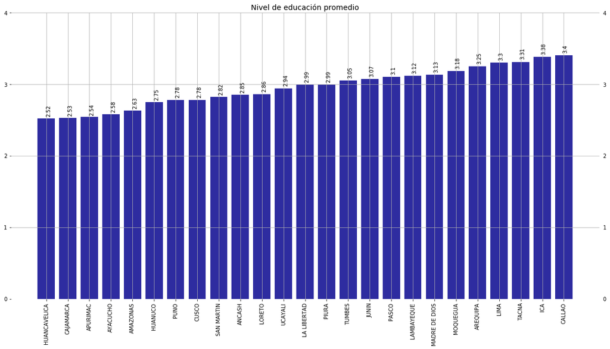

```python
x = enaho_ing['departamento'].astype(str)
y = round(enaho_ing['nivel_educacion'], 2)

plt.figure(figsize=(20,10))
plt.bar(x=x, height=y, color='#2e2ca0')
plt.title('Nivel de educación promedio', fontsize=14)
plt.grid(True)
plt.box(False)
plt.xticks(rotation=90)
plt.yticks(range(0, 5, 1))
plt.tick_params(bottom=True, top=False,
                left=True, right=False,
                labelleft=True, labelright=True,
                labelbottom=True, labeltop=False)


fx = 0.998
fy = 1.016

for i, v in enumerate(x):
    plt.text(i*fx,y[i]*fy,str(y[i]), color='black', fontsize = 10 ,rotation= 90)
```

### b. Segundo gráfico

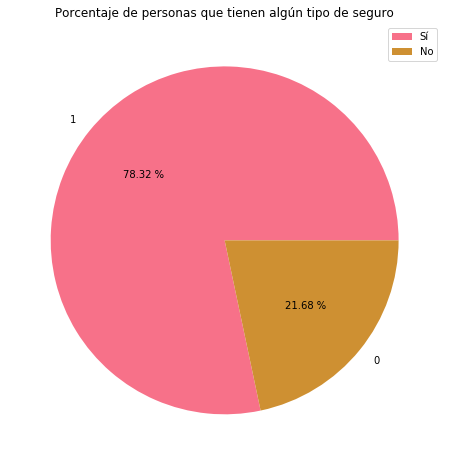

```python
plot = enaho['seguro'].value_counts().plot(kind='pie', autopct='%0.2f %%',
                                            figsize=(8, 8),
                                            title='Porcentaje de personas que tienen algún tipo de seguro')
plt.ylabel("")
plot.legend(['Sí','No'])
plt.show()
```

El porcentaje de personas que cuentan con al menos un seguro, ya sea ESSALUD, seguro privado, entidad prestadora de salud, seguro de FF.AA., SIS, seguro universitario, seguro escolar privado u otro es aproximadamente el 78% de la población en el Perú; mientras que el 22% de la población no cuenta con algún seguro. Esto quiere decir que más de la mitad de la población se encuentra asegurada.

### c. Tercer gráfico

#### 1. Eliminando los valores vacíos

```python
enaho['ingreso_mensual'].describe()
```

```
count     5197.000000
mean      4304.082932
std       5495.611425
min          0.000000
25%        480.000000
50%       2400.000000
75%       6000.000000
max      62000.000000
Name: ingreso_mensual, dtype: float64
```

```python
enaho["ingreso_mensual"].isna().sum()
```

```
15660
```

```python
enaho.shape
```

```
(20857, 7)
```

```python
no_nan = enaho.copy()
no_nan.dropna(subset = ["ingreso_mensual"], inplace=True)
```

```python
no_nan.shape
```

```
(5197, 7)
```

```python
nan_moda = enaho.copy()
nan_moda["ingreso_mensual"]=nan_moda["ingreso_mensual"].fillna(nan_moda["ingreso_mensual"].mode()[0])
nan_moda['ingreso_mensual'].mean()
```

```
3865.5376612168575
```

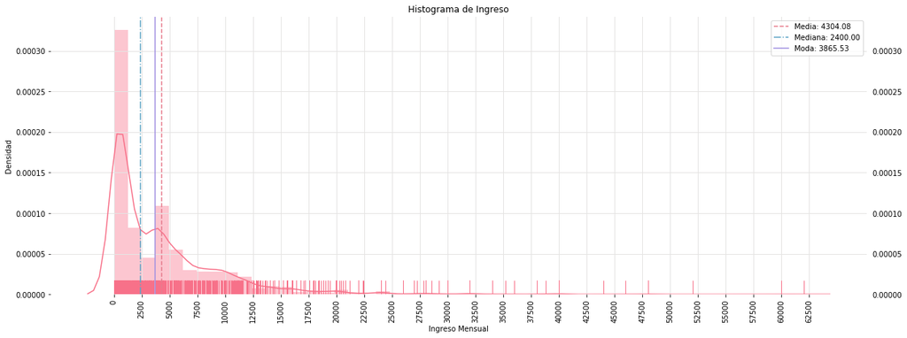

```python
plt.figure(figsize=(20, 7))

mean=no_nan['ingreso_mensual'].mean()
median=no_nan['ingreso_mensual'].median()
moda=3720.0

sns.set_palette("husl", 8)
sns.distplot(enaho['ingreso_mensual'], kde=True,
             rug=True).set(title='Histograma de Ingreso')
plt.axvline(mean, color='#e77c8d', linestyle='--', linewidth=1.5, label='Media: 4304.08')
plt.axvline(median, color='#5ea5c5', linestyle='-.', linewidth=1.5, label='Mediana: 2400.00')
plt.axvline(moda, color='#a291e1', linewidth=1.5, label='Moda: 3865.53')


plt.xticks(range(0, 62000+2500, 2500), rotation=90)
plt.xlabel("Ingreso Mensual")
plt.ylabel("Densidad")
plt.legend()
plt.grid(color='#E5E4E3', linestyle='-', linewidth=1)
plt.box(False)
plt.tick_params(bottom=True, top=False,
                left=True, right=False,
                labelleft=True, labelright=True,
                labelbottom=True, labeltop=False)
```

```python
no_nan['ingreso_mensual'].mean()
```

```
4304.082932461035
```

```python
enaho['ingreso_mensual'].mean() #son los mismos,ya que no toma en cuenta los nans
```

```
4304.082932461035
```